## lab1

- general Factorial Design and obtain Normal Probability plot of effects

Install and load FrF2 package

FrF2 stands for Fractional Factor 2-level design which will be learned later

Here we use 4 factors with total of 16 observations

```r
library(FrF2)
lab1_design <- FrF2(nruns=16, nfactors=4, randomize = FALSE)
lab1_response <- c(1.92, 11.28, 1.09, 5.75, 2.13, 9.53, 1.03, 5.35, 1.60, 11.73, 1.16, 4.68, 2.16, 9.11, 1.07, 5.30)
lab1_table<- add.response(lab1_design, response =lab1_response)
lab1_table
##     A  B  C  D lab1_response
## 1  -1 -1 -1 -1          1.92
## 2   1 -1 -1 -1         11.28
## 3  -1  1 -1 -1          1.09
## 4   1  1 -1 -1          5.75
## 5  -1 -1  1 -1          2.13
## 6   1 -1  1 -1          9.53
## 7  -1  1  1 -1          1.03
## 8   1  1  1 -1          5.35
## 9  -1 -1 -1  1          1.60
## 10  1 -1 -1  1         11.73
## 11 -1  1 -1  1          1.16
## 12  1  1 -1  1          4.68
## 13 -1 -1  1  1          2.16
## 14  1 -1  1  1          9.11
## 15 -1  1  1  1          1.07
## 16  1  1  1  1          5.30
## class=design, type= full factorial
```

Check the design. Note that the output is in the standard order of treatment combinations

Here the data are effect, should not be used as response variable.

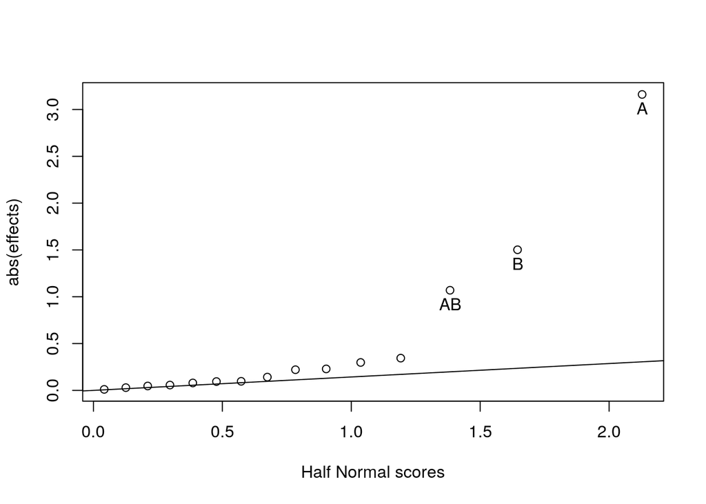

```r
lab1_model <-lm( lab1_response ~ A * B * C * D, data =lab1_table)
lab1_effects <- coef(lab1_model)[2:16]
library(daewr)
halfnorm(lab1_effects, names(lab1_effects), alpha = 0.05)
```

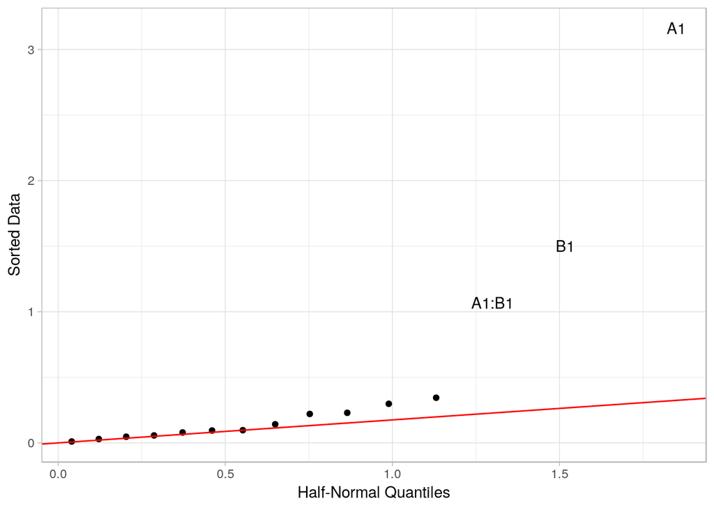

```r
library(AlgDesign)
gen.factorial(levels = 2, nVars = 5, varNames=c("A","B","C","D","E"))
library(ggplot2)
library(gghalfnorm)
gghalfnorm(x =lab1_effects,labs =names(lab1_effects), nlab = 3)+ theme_light()
```

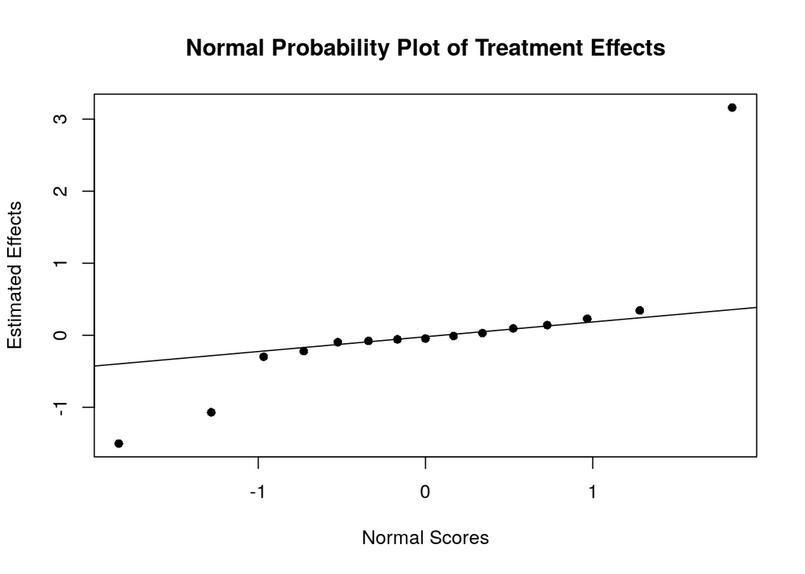

```
## zscore= 0.0417893 0.1256613 0.2104284 0.2967378 0.3853205 0.4770404 0.5729675 0.6744898 0.7835004 0.9027348 1.036433 1.191816 1.382994 1.644854 2.128045effp= 0.010625 0.029375 0.046875 0.056875 0.079375 0.094375 0.096875 0.141875 0.220625 0.229375 0.298125 0.344375 1.069375 1.501875 3.160625    A…
## 1  -1 -1 -1 -1 -1
## 2   1 -1 -1 -1 -1
## 3  -1  1 -1 -1 -1
## 4   1  1 -1 -1 -1
## 5  -1 -1  1 -1 -1
## 6   1 -1  1 -1 -1
## 7  -1  1  1 -1 -1
## 8   1  1  1 -1 -1
## 9  -1 -1 -1  1 -1
## 10  1 -1 -1  1 -1
## 11 -1  1 -1  1 -1
## 12  1  1 -1  1 -1
## 13 -1 -1  1  1 -1
## 14  1 -1  1  1 -1
```

[output cut: 18 more lines]

```r
qqnorm(lab1_effects, pch=16, ylab="Estimated Effects", xlab="Normal Scores", main="Normal Probability Plot of Treatment Effects")
qqline(lab1_effects)
```

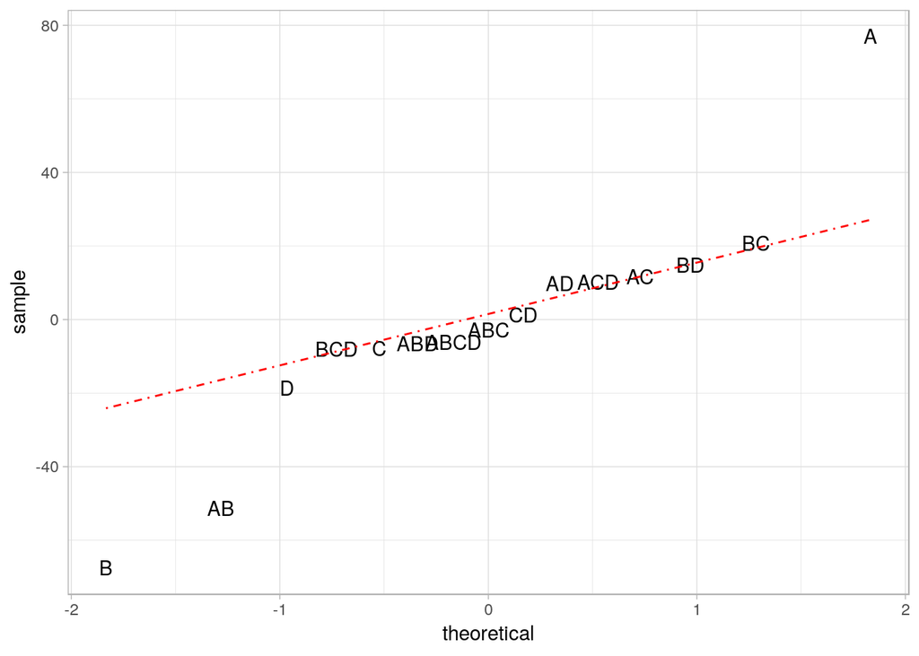

```r
# hw1_3 <- tribble(~factors, ~effect, "A",76.95, "B", -67.52,"C",-7.84, "D",-18.73, "AB", -51.32, "AC", 11.69, "AD",9.78, "BC", 20.78, "BD", 14.74, "CD", 1.27, "ABC", -2.82, "ABD", -6.5, "ACD",10.2, "BCD",-7.98, "ABCD",-6.25)

factors <-c("A","B","C","D","AB","AC","AD","BC","BD","CD","ABC","ABD", "ACD","BCD","ABCD")
effect <- c(76.95,-67.52,-7.84,-18.73,-51.32,11.69,9.78,20.78,14.74,1.27,-2.82,-6.5,10.2,-7.98,-6.25)
hw1_3 <- data.frame(factors,effect)
library(dplyr)

hw1_3_qq<-ggplot(hw1_3, aes(sample = effect),label=factors) + stat_qq()
hw1_3_new<-ggplot_build(hw1_3_qq)$data[[1]]
#### hw1_3_new$name<-hw1_3_new$name[order(hw1_3$effect)]
hw1_3_new%>%mutate(name=hw1_3$factors[order(hw1_3$effect)])%>%
ggplot(aes(theoretical,sample,label=name))+geom_text()+stat_qq_line(aes(sample = y), line.p = c(0.25, 0.75),linetype=4, col = "red")+ theme_light()
```

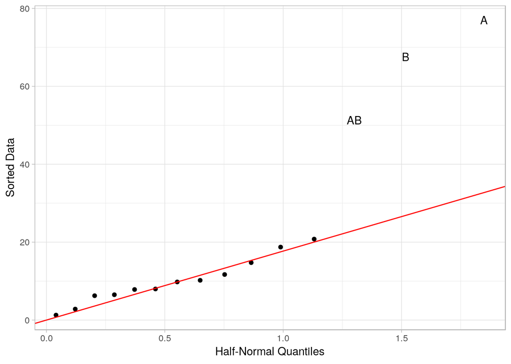

```r
library(gghalfnorm)
gghalfnorm(x = hw1_3$effect,labs = as.character(hw1_3$factors), nlab = 3)+ theme_light()
```

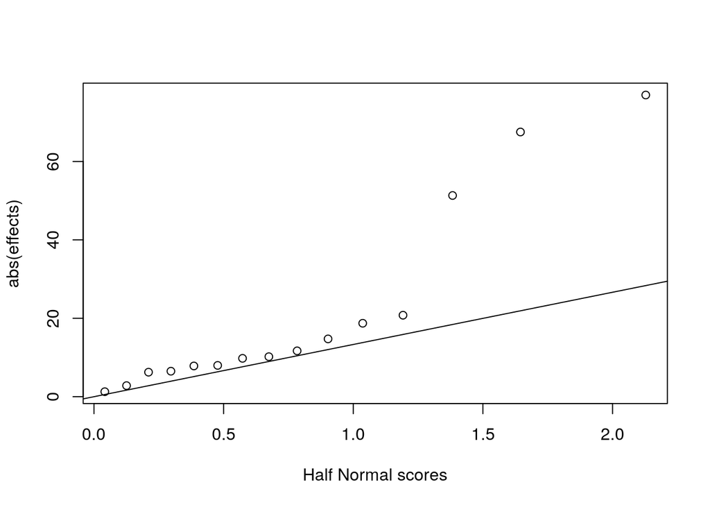

```
## zscore= 0.0417893 0.1256613 0.2104284 0.2967378 0.3853205 0.4770404 0.5729675 0.6744898 0.7835004 0.9027348 1.036433 1.191816 1.382994 1.644854 2.128045effp= 1.27 2.82 6.25 6.5 7.84 7.98 9.78 10.2 11.69 14.74 18.73 20.78 51.32 67.52 76.95
```

```r
library(daewr)
halfnorm(hw1_3$effect, names(as.character(hw1_3$factors)), alpha = 0.05)
```

## lab2

- Confounded Factorial Design Exercise 6.22

Install and load FrF2 package

Use FrF2 function as shown below to create the deign

blocks option is used to indicate confounding factor effects. Here AD and BC are confounded

nruns is for the number of runs, must be a power of 2

```r
library(FrF2)
lab2_des <- FrF2(nruns=16, nfactors = 4, blocks = c("AD", "BC"), randomize = FALSE)
lab2_des
```

```
##   run.no run.no.std.rp Blocks  A  B  C  D
## 1      1         4.1.1      1 -1 -1  1  1
## 2      2         6.1.2      1 -1  1 -1  1
## 3      3        11.1.3      1  1 -1  1 -1
## 4      4        13.1.4      1  1  1 -1 -1
##   run.no run.no.std.rp Blocks  A  B  C  D
## 5      5         2.2.1      2 -1 -1 -1  1
## 6      6         8.2.2      2 -1  1  1  1
## 7      7         9.2.3      2  1 -1 -1 -1
## 8      8        15.2.4      2  1  1  1 -1
##    run.no run.no.std.rp Blocks  A  B  C  D
## 9       9         3.3.1      3 -1 -1  1 -1
## 10     10         5.3.2      3 -1  1 -1 -1
## 11     11        12.3.3      3  1 -1  1  1
## 12     12        14.3.4      3  1  1 -1  1
##    run.no run.no.std.rp Blocks  A  B  C  D
## 13     13         1.4.1      4 -1 -1 -1 -1
## 14     14         7.4.2      4 -1  1  1 -1
## 15     15        10.4.3      4  1 -1 -1  1
## 16     16        16.4.4      4  1  1  1  1
## class=design, type= FrF2.blocked
## NOTE: columns run.no and run.no.std.rp  are annotation,
##  not part of the data frame
```

Change the order of AD and BC in the FrF2 function above and see the difference in the output design

If the given data file is sorted by Block, then sort the above design accordingly

If the given data file is sorted by standard order of trt combinations, then sort the above design accordingly Sort Design by Block and each factor to get standard order within each block

```r
lab2_des_sort1 <- lab2_des[order(lab2_des$Blocks, lab2_des$D ,lab2_des$C ,lab2_des$B,lab2_des$A ),]
lab2_des_sort1
```

```
##   run.no run.no.std.rp Blocks  A  B  C  D
## 4      4        13.1.4      1  1  1 -1 -1
## 3      3        11.1.3      1  1 -1  1 -1
## 2      2         6.1.2      1 -1  1 -1  1
## 1      1         4.1.1      1 -1 -1  1  1
##   run.no run.no.std.rp Blocks  A  B  C  D
## 7      7         9.2.3      2  1 -1 -1 -1
## 8      8        15.2.4      2  1  1  1 -1
## 5      5         2.2.1      2 -1 -1 -1  1
## 6      6         8.2.2      2 -1  1  1  1
##    run.no run.no.std.rp Blocks  A  B  C  D
## 10     10         5.3.2      3 -1  1 -1 -1
## 9       9         3.3.1      3 -1 -1  1 -1
## 12     12        14.3.4      3  1  1 -1  1
## 11     11        12.3.3      3  1 -1  1  1
##    run.no run.no.std.rp Blocks  A  B  C  D
## 13     13         1.4.1      4 -1 -1 -1 -1
## 14     14         7.4.2      4 -1  1  1 -1
## 15     15        10.4.3      4  1 -1 -1  1
## 16     16        16.4.4      4  1  1  1  1
## class=design, type= FrF2.blocked
## NOTE: columns run.no and run.no.std.rp  are annotation,
##  not part of the data frame
```

Sort Design by each factor to get standard order

```r
Design_Sort2 <- lab2_des[order(lab2_des$D ,lab2_des$C ,lab2_des$B,lab2_des$A),]
Design_Sort2
```

```
##    run.no run.no.std.rp Blocks  A  B  C  D
## 13     13         1.4.1      4 -1 -1 -1 -1
##   run.no run.no.std.rp Blocks A  B  C  D
## 7      7         9.2.3      2 1 -1 -1 -1
##    run.no run.no.std.rp Blocks  A B  C  D
## 10     10         5.3.2      3 -1 1 -1 -1
##   run.no run.no.std.rp Blocks A B  C  D
## 4      4        13.1.4      1 1 1 -1 -1
##   run.no run.no.std.rp Blocks  A  B C  D
## 9      9         3.3.1      3 -1 -1 1 -1
##   run.no run.no.std.rp Blocks A  B C  D
## 3      3        11.1.3      1 1 -1 1 -1
##    run.no run.no.std.rp Blocks  A B C  D
## 14     14         7.4.2      4 -1 1 1 -1
##   run.no run.no.std.rp Blocks  A  B  C  D
## 8      8        15.2.4      2  1  1  1 -1
## 5      5         2.2.1      2 -1 -1 -1  1
##    run.no run.no.std.rp Blocks A  B  C D
## 15     15        10.4.3      4 1 -1 -1 1
##   run.no run.no.std.rp Blocks  A B  C D
## 2      2         6.1.2      1 -1 1 -1 1
##    run.no run.no.std.rp Blocks A B  C D
## 12     12        14.3.4      3 1 1 -1 1
##   run.no run.no.std.rp Blocks  A  B C D
## 1      1         4.1.1      1 -1 -1 1 1
##    run.no run.no.std.rp Blocks A  B C D
## 11     11        12.3.3      3 1 -1 1 1
##   run.no run.no.std.rp Blocks  A B C D
## 6      6         8.2.2      2 -1 1 1 1
##    run.no run.no.std.rp Blocks A B C D
## 16     16        16.4.4      4 1 1 1 1
## class=design, type= FrF2.blocked
## NOTE: columns run.no and run.no.std.rp  are annotation,
##  not part of the data frame
```

Import the Example Excel file

```r
lab2_example <- readxl::read_xlsx("Example.xlsx")
```

This data file is in the standard order

Therefore, use the Design_Sort2 to combine response

```r
lab2_obs <- cbind(Design_Sort2,lab2_example)
lab2_obs
```

```
##    Blocks  A  B  C  D StdOrder  A  B  C  D Block  UEC
## 13      4 -1 -1 -1 -1      (1) -1 -1 -1 -1     2 0.75
## 7       2  1 -1 -1 -1        a  1 -1 -1 -1     3 0.98
## 10      3 -1  1 -1 -1        b -1  1 -1 -1     1 0.72
## 4       1  1  1 -1 -1       ab  1  1 -1 -1     4 0.98
## 9       3 -1 -1  1 -1        c -1 -1  1 -1     1 0.63
## 3       1  1 -1  1 -1       ac  1 -1  1 -1     4 0.67
## 14      4 -1  1  1 -1       bc -1  1  1 -1     2 0.65
## 8       2  1  1  1 -1      abc  1  1  1 -1     3 0.80
## 5       2 -1 -1 -1  1        d -1 -1 -1  1     3 0.60
## 15      4  1 -1 -1  1       ad  1 -1 -1  1     2 0.81
## 2       1 -1  1 -1  1       bd -1  1 -1  1     4 0.63
## 12      3  1  1 -1  1      abd  1  1 -1  1     1 0.79
## 1       1 -1 -1  1  1       cd -1 -1  1  1     4 0.56
## 11      3  1 -1  1  1      acd  1 -1  1  1     1 0.65
## 6       2 -1  1  1  1      bcd -1  1  1  1     3 0.55
## 16      4  1  1  1  1     abcd  1  1  1  1     2 0.69
```

Note the Block numbers are different in the design and the actual data file

Therefore, use Block numbers in the actual data file for the analysis

First, change it to a factor

```r
lab2_obs$Blk <-as.factor(lab2_obs$Block)

lab2_fit1 <- aov(UEC ~ Blk + A * B * C * D, data =lab2_obs)
lab2_effects <- coef(lab2_fit1)
lab2_effects
```

```
## (Intercept)        Blk2        Blk3        Blk4          A1          B1
##     0.69750     0.02750     0.03500     0.01250     0.08000     0.01000
##          C1          D1       A1:B1       A1:C1       B1:D1       C1:D1
##    -0.06625    -0.05625     0.00875    -0.02750    -0.00500     0.01875
##    A1:B1:C1    A1:B1:D1    A1:C1:D1    B1:C1:D1
##     0.01125    -0.00875     0.01000    -0.01000
```

```r
lab2_l <- length(lab2_effects)
```

Selects the non-block effects that do not have the value of NA

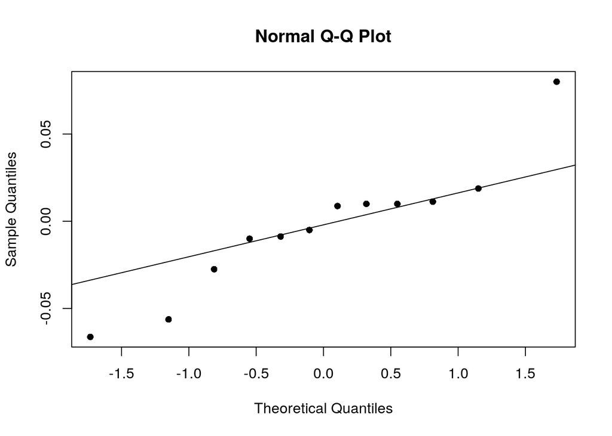

```r
lab2_effects <-lab2_effects[5:lab2_l]
#lab2_effects <-lab2_effects[!is.na(d)]
qqnorm(lab2_effects, pch=16)
qqline(lab2_effects)
```

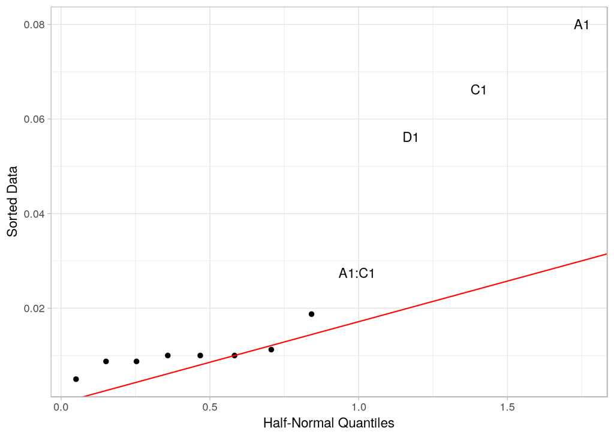

```r
library(ggplot2)
library(gghalfnorm)
gghalfnorm(x =lab2_effects,labs =names(lab2_effects), nlab=4)+ theme_light()
```

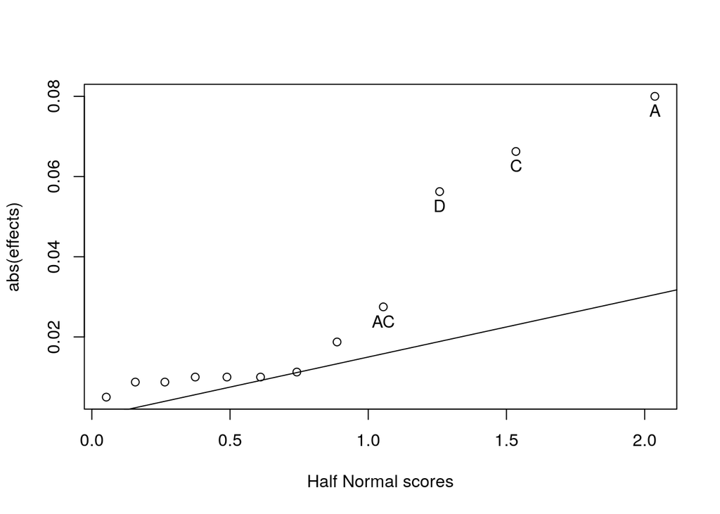

```r
library(daewr)
halfnorm(lab2_effects, names(lab2_effects), alpha = 0.15)
```

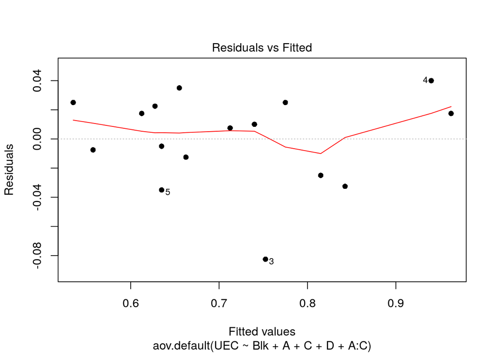

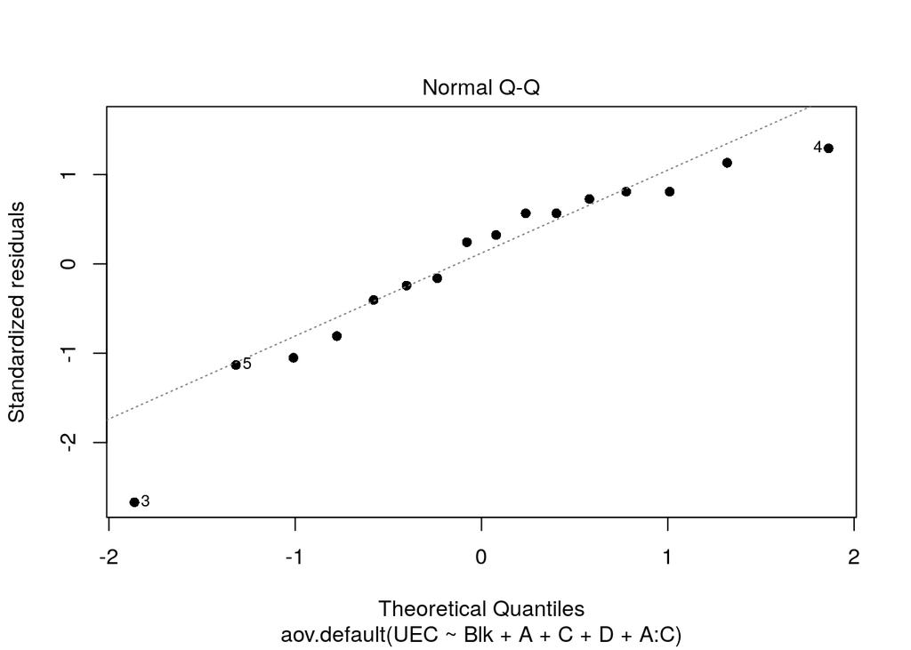

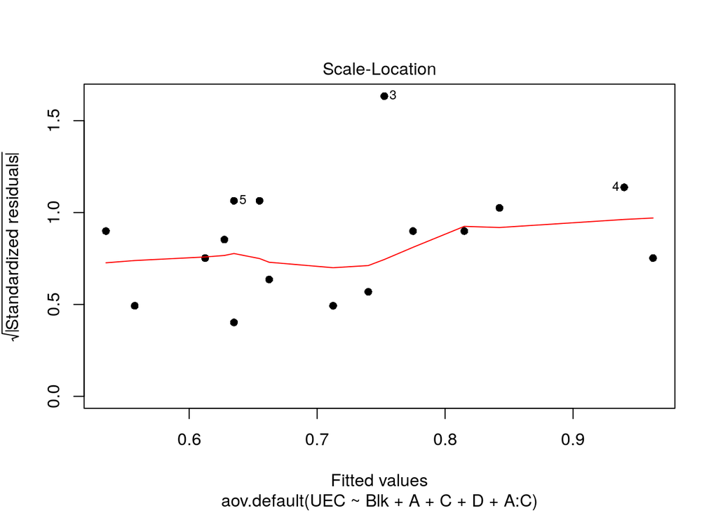

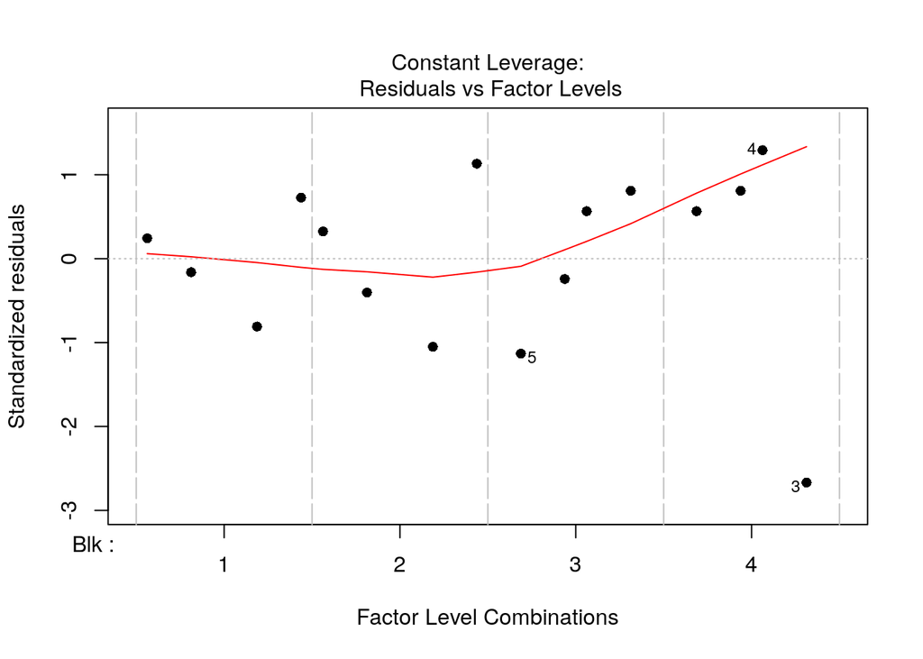

```
## zscore= 0.05224518 0.1573107 0.264147 0.3740954 0.4887764 0.6102946 0.741594 0.8871466 1.054472 1.258162 1.534121 2.036834effp= 0.005 0.00875 0.00875 0.01 0.01 0.01 0.01125 0.01875 0.0275 0.05625 0.06625 0.08            Df  Sum Sq Mean Sq F value   Pr(>F)
## Blk          3 0.00292 0.00097   0.510 0.686557
## A            1 0.10240 0.10240  53.542 8.25e-05 ***
## C            1 0.07023 0.07023  36.719 0.000303 ***
## D            1 0.05063 0.05063  26.471 0.000880 ***
## A:C          1 0.01210 0.01210   6.327 0.036071 *
## Residuals    8 0.01530 0.00191
## ---
## Signif. codes:  0 '***' 0.001 '**' 0.01 '*' 0.05 '.' 0.1 ' ' 1
```

```r
lab2_fit2<- aov(UEC ~ Blk + A + C + D + A:C, data = lab2_obs)
summary(lab2_fit2)
plot(lab2_fit2, pch=16)
```

## lab3

- Example 8.2

```r
library(FrF2)
design_lab3_1 <- FrF2(nfactors = 5, resolution =5, alias.block.2fis = TRUE, randomize = FALSE)
summary(design_lab3_1)
## Call:
## FrF2(nfactors = 5, resolution = 5, alias.block.2fis = TRUE, randomize = FALSE)
##
## Experimental design of type  FrF2
## 16  runs
##
## Factor settings (scale ends):
##    A  B  C  D  E
## 1 -1 -1 -1 -1 -1
## 2  1  1  1  1  1
##
## Design generating information:
## $legend
## [1] A=A B=B C=C D=D E=E
##
## $generators
## [1] E=ABCD
##
##
## Alias structure:
## [[1]]
## [1] no aliasing among main effects and 2fis
##
##
## The design itself:
##     A  B  C  D  E
## 1  -1 -1 -1 -1  1
## 2   1 -1 -1 -1 -1
## 3  -1  1 -1 -1 -1
## 4   1  1 -1 -1  1
## 5  -1 -1  1 -1 -1
## 6   1 -1  1 -1  1
## 7  -1  1  1 -1  1
## 8   1  1  1 -1 -1
## 9  -1 -1 -1  1 -1
## 10  1 -1 -1  1  1
## 11 -1  1 -1  1  1
## 12  1  1 -1  1 -1
## 13 -1 -1  1  1  1
## 14  1 -1  1  1 -1
## 15 -1  1  1  1 -1
## 16  1  1  1  1  1
## class=design, type= FrF2
```

The same design can be obtained from the following options too

Here nruns and generators are given and resolution is not given

Since I=ABCDE the generator which is equivalent to E=ABCD, the column E is created using ABCD

```r
design_lab3_2 <- FrF2(nfactors = 5, nruns=2^4, generators = "ABCD", alias.block.2fis = TRUE, randomize = FALSE)
summary(design_lab3_2)
## Call:
## FrF2(nfactors = 5, nruns = 2^4, generators = "ABCD", alias.block.2fis = TRUE,
##     randomize = FALSE)
##
## Experimental design of type  FrF2.generators
## 16  runs
##
## Factor settings (scale ends):
##    A  B  C  D  E
## 1 -1 -1 -1 -1 -1
## 2  1  1  1  1  1
##
## Design generating information:
## $legend
## [1] A=A B=B C=C D=D E=E
##
## $generators
## [1] E=ABCD
##
##
## Alias structure:
## [[1]]
## [1] no aliasing among main effects and 2fis
##
##
## The design itself:
##     A  B  C  D  E
## 1  -1 -1 -1 -1  1
## 2   1 -1 -1 -1 -1
## 3  -1  1 -1 -1 -1
## 4   1  1 -1 -1  1
## 5  -1 -1  1 -1 -1
## 6   1 -1  1 -1  1
## 7  -1  1  1 -1  1
## 8   1  1  1 -1 -1
## 9  -1 -1 -1  1 -1
## 10  1 -1 -1  1  1
## 11 -1  1 -1  1  1
## 12  1  1 -1  1 -1
## 13 -1 -1  1  1  1
## 14  1 -1  1  1 -1
## 15 -1  1  1  1 -1
## 16  1  1  1  1  1
## class=design, type= FrF2.generators
```

```r
lab3_y <- c(8, 9, 34, 52,16,22,45,60, 6, 10, 30, 50, 15, 21, 44, 63)
table_lab3 <- add.response(design_lab3_1,lab3_y)
table_lab3
model_lab3 <- aov(lab3_y ~ A*B*C*D*E, data= table_lab3)
##     A  B  C  D  E lab3_y
## 1  -1 -1 -1 -1  1      8
## 2   1 -1 -1 -1 -1      9
## 3  -1  1 -1 -1 -1     34
## 4   1  1 -1 -1  1     52
## 5  -1 -1  1 -1 -1     16
## 6   1 -1  1 -1  1     22
## 7  -1  1  1 -1  1     45
## 8   1  1  1 -1 -1     60
## 9  -1 -1 -1  1 -1      6
## 10  1 -1 -1  1  1     10
## 11 -1  1 -1  1  1     30
## 12  1  1 -1  1 -1     50
## 13 -1 -1  1  1  1     15
## 14  1 -1  1  1 -1     21
## 15 -1  1  1  1 -1     44
## 16  1  1  1  1  1     63
## class=design, type= FrF2
```

The coefficients in this fitted model gives only half of the estimated effect

because each factor has two levels and the coefficient is only for one level of factor

The true value of estimated effect is double of the following effects

However, it does not affect the normal plot because each effect is half of its true value

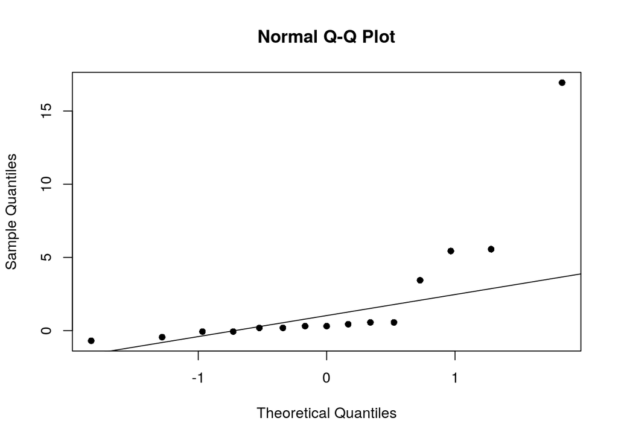

```r
effect_lab3 <-coef(model_lab3)
qqnorm(effect_lab3[2:length(effect_lab3)], pch=16)
qqline(effect_lab3[2:length(effect_lab3)])
```

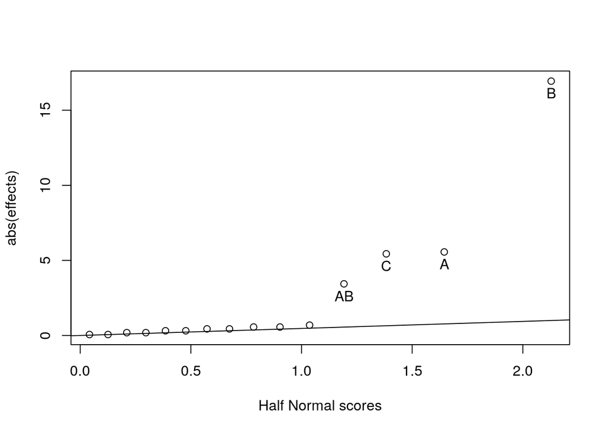

```
## zscore= 0.0417893 0.1256613 0.2104284 0.2967378 0.3853205 0.4770404 0.5729675 0.6744898 0.7835004 0.9027348 1.036433 1.191816 1.382994 1.644854 2.128045effp= 0.0625 0.0625 0.1875 0.1875 0.3125 0.3125 0.4375 0.4375 0.5625 0.5625 0.6875 3.4375 5.4375 5.5625 16.9375
```

```r
daewr::halfnorm(effect_lab3[2:length(effect_lab3)], names(effect_lab3[2:length(effect_lab3)]), alpha = 0.05)
```

## Lab4

- Mixed Models

See Chapter 13-Part 4 Note for the description of data.

```r
lab4_table <- readxl::read_xlsx("Table13_9.xlsx")
lab4_table$A <- as.factor(lab4_table$Temp)
lab4_table$B <- as.factor(lab4_table$Operator)
lab4_table$C <- as.factor(lab4_table$Gauge)
```

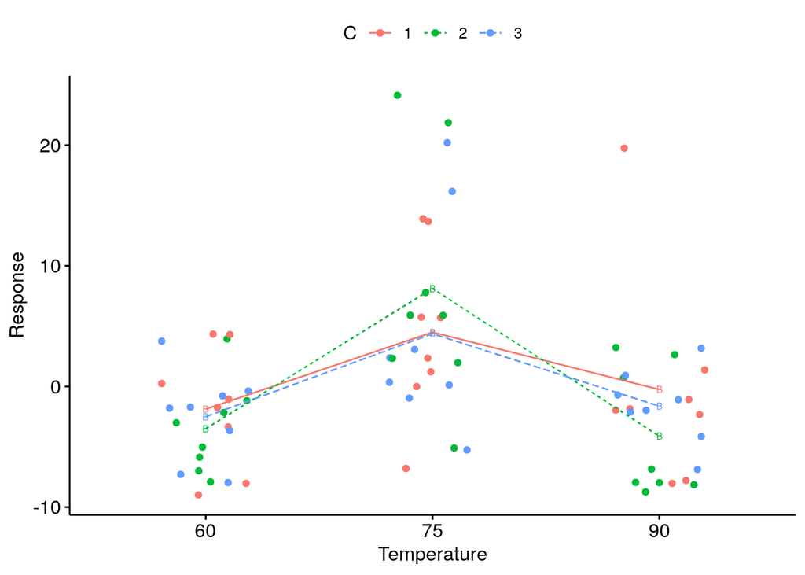

```r
ggpubr::ggline(data = lab4_table, x = "A", y = "y", add = c("mean", "jitter"), shape= "B", color = "C", linetype = "C", ylab= "Response", xlab="Temperature")
```

```
## No summary function supplied, defaulting to `mean_se()
```

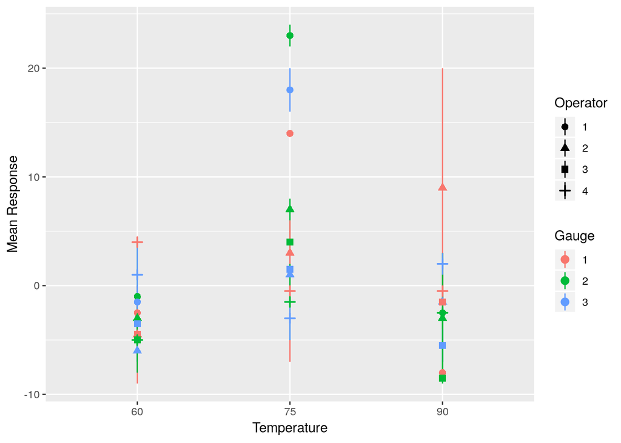

```r
ggplot(data = lab4_table, aes(x = A, y = y, shape = B, color=C)) + stat_summary() + labs(y= "Mean Response", x="Temperature", shape="Operator", color = "Gauge")
```

```r
library(lme4)
lab4_model1 <- lmer(formula = y ~ A + (1|B) + A:(1|B) + (1|C) + A:(1|C) + (1|B:C) + A:(1|B:C), data=lab4_table, REML = TRUE)
summary(lab4_model1)
```

```
## Linear mixed model fit by REML ['lmerMod']
## Formula: y ~ A + (1 | B) + A:(1 | B) + (1 | C) + A:(1 | C) + (1 | B:C) +
##     A:(1 | B:C)
##    Data: lab4_table
##
## REML criterion at convergence: 460.2
##
## Scaled residuals:
##     Min      1Q  Median      3Q     Max
## -1.9364 -0.5829 -0.0539  0.4910  3.5872
##
## Random effects:
##  Groups   Name        Variance  Std.Dev.
##  B.C      (Intercept)  0.000000 0.00000
##  B.C.1    (Intercept)  0.000000 0.00000
##  B        (Intercept)  5.733772 2.39453
##  B.1      (Intercept)  0.007715 0.08784
##  C        (Intercept)  0.000000 0.00000
##  C.1      (Intercept)  0.000000 0.00000
##  Residual             37.926347 6.15844
## Number of obs: 72, groups:  B:C, 12; B, 4; C, 3
##
## Fixed effects:
##             Estimate Std. Error t value
## (Intercept)   -2.625      1.737  -1.512
## A75            8.292      1.778   4.664
## A90            0.625      1.778   0.352
##
## Correlation of Fixed Effects:
##     (Intr) A75
## A75 -0.512
## A90 -0.512  0.500
## convergence code: 0
## Model is nearly unidentifiable: large eigenvalue ratio
##  - Rescale variables?
```

```r
anova(lab4_model1)
```

```
## Analysis of Variance Table
##   Df Sum Sq Mean Sq F value
## A  2 1023.4  511.68  13.491
```

```r
confint(lab4_model1)
```

```
## Computing profile confidence intervals ...
```

```
##                 2.5 %     97.5 %
## .sig01       0.000000  3.0526009
## .sig02       0.000000  3.0526009
## .sig03       0.000000  5.7780513
## .sig04       0.000000        Inf
## .sig05       0.000000  2.4557420
## .sig06       0.000000  2.4557420
## .sigma       5.174434  7.2494727
## (Intercept) -6.123429  0.8734314
## A75          4.809837 11.7734966
## A90         -2.856830  4.1068300
```

```r
lab4_model2 <- lmer(formula = y ~ A + (1|B) + (1|A:B) + (1|C) + (1|A:C) + (1|B:C) + (1|A:B:C), data=lab4_table, REML = TRUE)
summary(lab4_model2)
```

```
## Linear mixed model fit by REML ['lmerMod']
## Formula: y ~ A + (1 | B) + (1 | A:B) + (1 | C) + (1 | A:C) + (1 | B:C) +
##     (1 | A:B:C)
##    Data: lab4_table
##
## REML criterion at convergence: 435.9
##
## Scaled residuals:
##     Min      1Q  Median      3Q     Max
## -1.7201 -0.6468 -0.1159  0.6592  4.0073
##
## Random effects:
##  Groups   Name        Variance Std.Dev.
##  A:B:C    (Intercept)  0.0000  0.000
##  B:C      (Intercept)  1.2678  1.126
##  A:B      (Intercept) 26.7438  5.171
##  A:C      (Intercept)  0.7073  0.841
##  B        (Intercept)  0.0000  0.000
##  C        (Intercept)  0.0000  0.000
##  Residual             19.9924  4.471
## Number of obs: 72, groups:
## A:B:C, 36; B:C, 12; A:B, 12; A:C, 9; B, 4; C, 3
##
## Fixed effects:
##             Estimate Std. Error t value
## (Intercept)   -2.625      2.804  -0.936
## A75            8.292      3.938   2.105
## A90            0.625      3.938   0.159
##
## Correlation of Fixed Effects:
##     (Intr) A75
## A75 -0.702
## A90 -0.702  0.500
```

```r
anova(lab4_model2)
```

```
## Analysis of Variance Table
##   Df Sum Sq Mean Sq F value
## A  2 109.93  54.965  2.7493
```

```r
confint(lab4_model2)
```

```
## Computing profile confidence intervals ...
```

```
##                 2.5 %    97.5 %
## .sig01       0.000000  3.124056
## .sig02       0.000000  3.245387
## .sig03       2.655719  7.359069
## .sig04       0.000000  2.826874
## .sig05       0.000000  5.474702
## .sig06       0.000000  2.514992
## .sigma       3.699082  5.567516
## (Intercept) -7.820893  2.570974
## A75          1.026588 15.556746
## A90         -6.640079  7.890079
```

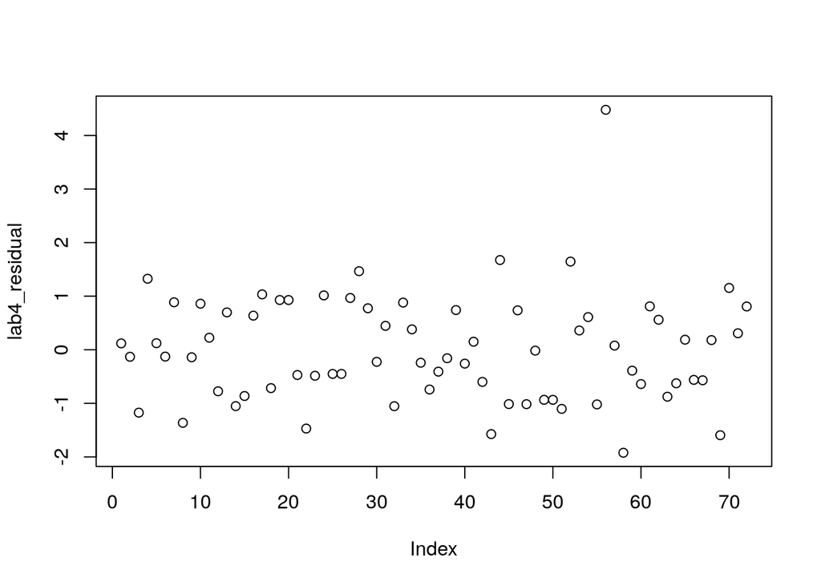

```r
lab4_residual <- rstudent(lab4_model2)
plot(lab4_residual)
```

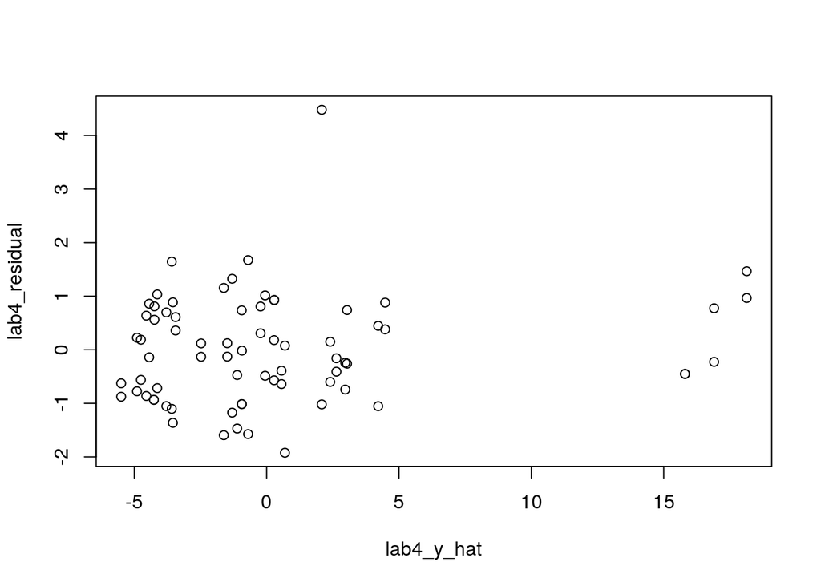

```r
lab4_y_hat <- fitted(lab4_model2)
plot(lab4_y_hat,lab4_residual)
```

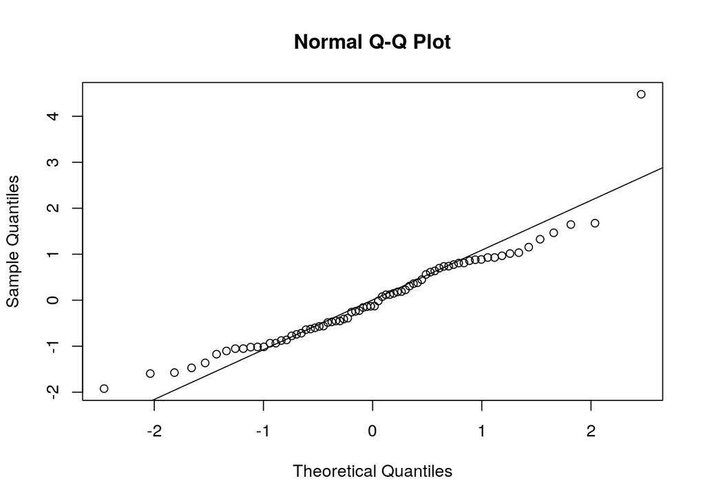

```r
qqnorm(lab4_residual)
qqline(lab4_residual)
```

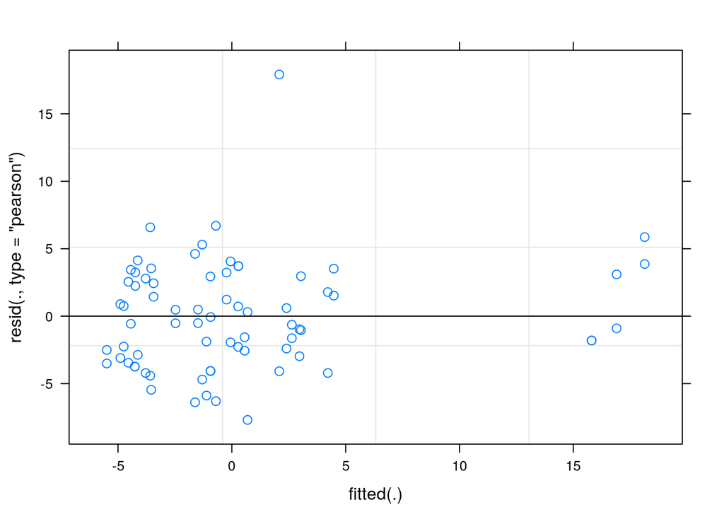

```r
plot(lab4_model2)
```

```r
library(emmeans)
lsmeans(lab4_model2, pairwise ~ A, adjust = c("tukey"))
```

```
## $lsmeans
##  A  lsmean  SE   df lower.CL upper.CL
##  60  -2.62 2.8 9.16   -8.950     3.70
##  75   5.67 2.8 9.16   -0.659    11.99
##  90  -2.00 2.8 9.16   -8.325     4.33
##
## Degrees-of-freedom method: kenward-roger
## Confidence level used: 0.95
##
## $contrasts
##  contrast estimate   SE   df t.ratio p.value
##  60 - 75    -8.292 3.94 6.16 -2.105  0.1669
##  60 - 90    -0.625 3.94 6.16 -0.159  0.9862
##  75 - 90     7.667 3.94 6.16  1.947  0.2045
##
## P value adjustment: tukey method for comparing a family of 3 estimates
```

```r
lab4_model3 <- lmer(y ~ A + (1|B) + (1|A:B) + (1|C) + (1|A:C) + (1|B:C) + (1|A:B:C), data=lab4_table, REML = FALSE)

summary(lab4_model3)
```

```
## Linear mixed model fit by maximum likelihood  ['lmerMod']
## Formula: y ~ A + (1 | B) + (1 | A:B) + (1 | C) + (1 | A:C) + (1 | B:C) +
##     (1 | A:B:C)
##    Data: lab4_table
##
##      AIC      BIC   logLik deviance df.resid
##    467.2    489.9   -223.6    447.2       62
##
## Scaled residuals:
##     Min      1Q  Median      3Q     Max
## -1.7160 -0.6624 -0.1054  0.6374  4.0526
##
## Random effects:
##  Groups   Name        Variance Std.Dev.
##  A:B:C    (Intercept)  0.0000  0.0000
##  B:C      (Intercept)  1.1216  1.0591
##  A:B      (Intercept) 19.2861  4.3916
##  A:C      (Intercept)  0.4056  0.6369
##  B        (Intercept)  0.0000  0.0000
##  C        (Intercept)  0.0000  0.0000
##  Residual             20.2525  4.5003
## Number of obs: 72, groups:
## A:B:C, 36; B:C, 12; A:B, 12; A:C, 9; B, 4; C, 3
##
## Fixed effects:
##             Estimate Std. Error t value
## (Intercept)   -2.625      2.428  -1.081
## A75            8.292      3.406   2.434
## A90            0.625      3.406   0.183
##
## Correlation of Fixed Effects:
##     (Intr) A75
## A75 -0.701
## A90 -0.701  0.500
```

```r
anova(lab4_model3)
```

```
## Analysis of Variance Table
##   Df Sum Sq Mean Sq F value
## A  2 148.88  74.438  3.6755
```

## Lab5

- Split-Plot Design

```r
table14_16 <- readxl::read_xlsx("Table14_16.xlsx")
table14_16$R <- as.factor(table14_16$Rep)
table14_16$A <- as.factor(table14_16$Pulp)
table14_16$B <- as.factor(table14_16$Temp)
```

Fit the model assuming RepxAxB is negligible and use to compute error

Fit the model assuming all the terms containing both Rep and B are negligible and use to compute error

```r
library("lme4")
model_lab5_1 <- lmer(formula = Strength ~ (1|R) + A + (1|R:A) + B + (1|R:B) + A:B, data=table14_16, REML = TRUE)
summary(model_lab5_1)
```

```
## Linear mixed model fit by REML ['lmerMod']
## Formula: Strength ~ (1 | R) + A + (1 | R:A) + B + (1 | R:B) + A:B
##    Data: table14_16
##
## REML criterion at convergence: 122.3
##
## Scaled residuals:
##     Min      1Q  Median      3Q     Max
## -1.1366 -0.6874  0.1482  0.5104  1.6542
##
## Random effects:
##  Groups   Name        Variance Std.Dev.
##  R:B      (Intercept) 0.000    0.000
##  R:A      (Intercept) 1.274    1.129
##  R        (Intercept) 2.476    1.573
##  Residual             3.972    1.993
## Number of obs: 36, groups:  R:B, 12; R:A, 9; R, 3
##
## Fixed effects:
##             Estimate Std. Error t value
## (Intercept)  29.6667     1.6044  18.491
## A2            3.6667     1.8702   1.961
## A3            1.0000     1.8702   0.535
## B225          5.0000     1.6273   3.073
## B250          9.6667     1.6273   5.940
## B275          9.3333     1.6273   5.735
## A2:B225       0.6667     2.3014   0.290
## A3:B225      -5.6667     2.3014  -2.462
## A2:B250      -3.3333     2.3014  -1.448
## A3:B250      -5.6667     2.3014  -2.462
## A2:B275      -0.6667     2.3014  -0.290
## A3:B275       0.3333     2.3014   0.145
##
## Correlation of Fixed Effects:
##         (Intr) A2     A3     B225   B250   B275   A2:B22 A3:B22 A2:B25
## A2      -0.583
## A3      -0.583  0.500
## B225    -0.507  0.435  0.435
## B250    -0.507  0.435  0.435  0.500
## B275    -0.507  0.435  0.435  0.500  0.500
## A2:B225  0.359 -0.615 -0.308 -0.707 -0.354 -0.354
## A3:B225  0.359 -0.308 -0.615 -0.707 -0.354 -0.354  0.500
## A2:B250  0.359 -0.615 -0.308 -0.354 -0.707 -0.354  0.500  0.250
## A3:B250  0.359 -0.308 -0.615 -0.354 -0.707 -0.354  0.250  0.500  0.500
## A2:B275  0.359 -0.615 -0.308 -0.354 -0.354 -0.707  0.500  0.250  0.500
## A3:B275  0.359 -0.308 -0.615 -0.354 -0.354 -0.707  0.250  0.500  0.250
##         A3:B25 A2:B27
## A2
## A3
## B225
## B250
## B275
## A2:B225
## A3:B225
## A2:B250
## A3:B250
## A2:B275  0.250
## A3:B275  0.500  0.500
```

```r
anova(model_lab5_1)
```

```
## Analysis of Variance Table
##     Df Sum Sq Mean Sq F value
## A    2  56.23  28.116  7.0781
## B    3 434.08 144.694 36.4266
## A:B  6  75.17  12.528  3.1538
```

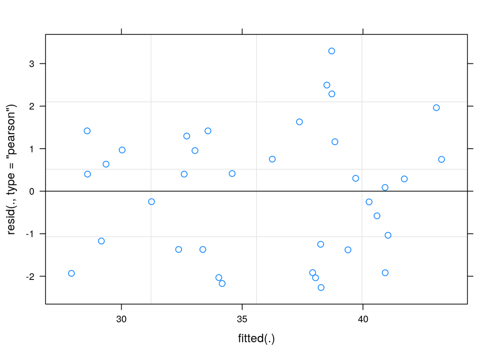

```r
plot(model_lab5_1)
```

```r
model_lab5_2 <- lmer(formula = Strength ~ (1|R) + A + (1|R:A) + B + A:B, data=table14_16, REML = TRUE)
summary(model_lab5_2)
```

```
## Linear mixed model fit by REML ['lmerMod']
## Formula: Strength ~ (1 | R) + A + (1 | R:A) + B + A:B
##    Data: table14_16
##
## REML criterion at convergence: 122.3
##
## Scaled residuals:
##     Min      1Q  Median      3Q     Max
## -1.1366 -0.6874  0.1482  0.5104  1.6542
##
## Random effects:
##  Groups   Name        Variance Std.Dev.
##  R:A      (Intercept) 1.274    1.129
##  R        (Intercept) 2.476    1.573
##  Residual             3.972    1.993
## Number of obs: 36, groups:  R:A, 9; R, 3
##
## Fixed effects:
##             Estimate Std. Error t value
## (Intercept)  29.6667     1.6044  18.491
## A2            3.6667     1.8702   1.961
## A3            1.0000     1.8702   0.535
## B225          5.0000     1.6273   3.073
## B250          9.6667     1.6273   5.940
## B275          9.3333     1.6273   5.735
## A2:B225       0.6667     2.3014   0.290
## A3:B225      -5.6667     2.3014  -2.462
## A2:B250      -3.3333     2.3014  -1.448
## A3:B250      -5.6667     2.3014  -2.462
## A2:B275      -0.6667     2.3014  -0.290
## A3:B275       0.3333     2.3014   0.145
##
## Correlation of Fixed Effects:
##         (Intr) A2     A3     B225   B250   B275   A2:B22 A3:B22 A2:B25
## A2      -0.583
## A3      -0.583  0.500
## B225    -0.507  0.435  0.435
## B250    -0.507  0.435  0.435  0.500
## B275    -0.507  0.435  0.435  0.500  0.500
## A2:B225  0.359 -0.615 -0.308 -0.707 -0.354 -0.354
## A3:B225  0.359 -0.308 -0.615 -0.707 -0.354 -0.354  0.500
## A2:B250  0.359 -0.615 -0.308 -0.354 -0.707 -0.354  0.500  0.250
## A3:B250  0.359 -0.308 -0.615 -0.354 -0.707 -0.354  0.250  0.500  0.500
## A2:B275  0.359 -0.615 -0.308 -0.354 -0.354 -0.707  0.500  0.250  0.500
## A3:B275  0.359 -0.308 -0.615 -0.354 -0.354 -0.707  0.250  0.500  0.250
##         A3:B25 A2:B27
## A2
## A3
## B225
## B250
## B275
## A2:B225
## A3:B225
## A2:B250
## A3:B250
## A2:B275  0.250
## A3:B275  0.500  0.500
```

```r
anova(model_lab5_2)
```

```
## Analysis of Variance Table
##     Df Sum Sq Mean Sq F value
## A    2  56.23  28.116  7.0781
## B    3 434.08 144.694 36.4266
## A:B  6  75.17  12.528  3.1538
```

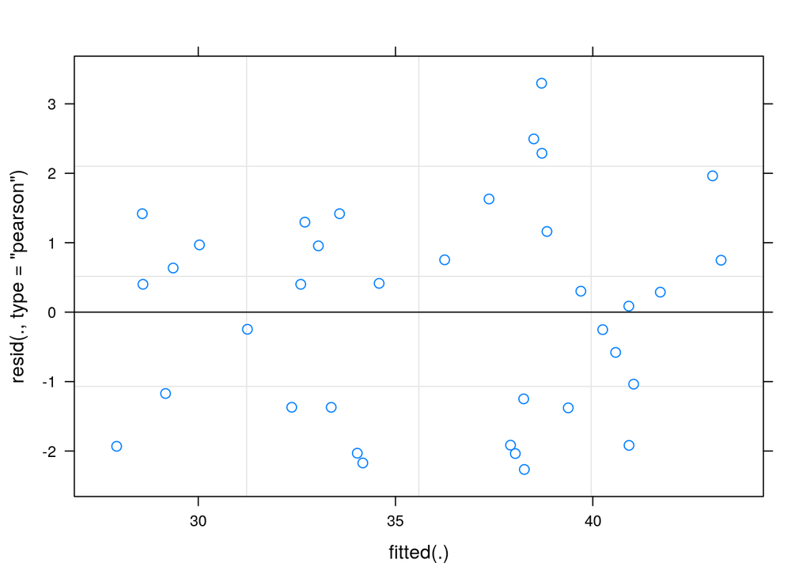

```r
plot(model_lab5_2)
```

In this example, you may not see a difference in F values of B and AB because RxB variance is estimated to be zero. If it was not zero, then results in two models would be different

```r
library("GAD")
table14_16$RR <- as.random(table14_16$Rep)
table14_16$AA <- as.fixed(table14_16$Pulp)
table14_16$BB <- as.fixed(table14_16$Temp)
```

This gives complete ANOVA table and does not give estimated variances

Fit the model assuming all the terms containing both Rep and B are negligible and use to compute error

```r
model_lab5_3 <- aov(formula = Strength ~ RR + AA + AA%in%RR + BB + AA:BB, data=table14_16)
gad(model_lab5_3)
```

```
## Analysis of Variance Table
##
## Response: Strength
##          Df Sum Sq Mean Sq F value    Pr(>F)
## RR        2  77.56  38.778  9.7622  0.001345 **
## AA        2 128.39  64.194  7.0781  0.048537 *
## BB        3 434.08 144.694 36.4266 7.449e-08 ***
## RR:AA     4  36.28   9.069  2.2832  0.100284
## AA:BB     6  75.17  12.528  3.1538  0.027109 *
## Residual 18  71.50   3.972
## ---
## Signif. codes:  0 '***' 0.001 '**' 0.01 '*' 0.05 '.' 0.1 ' ' 1
```

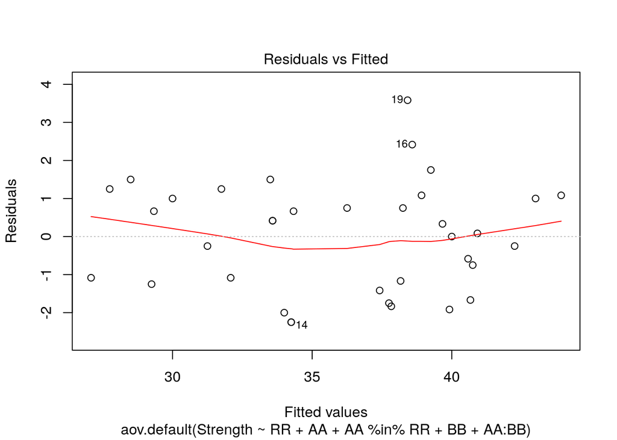

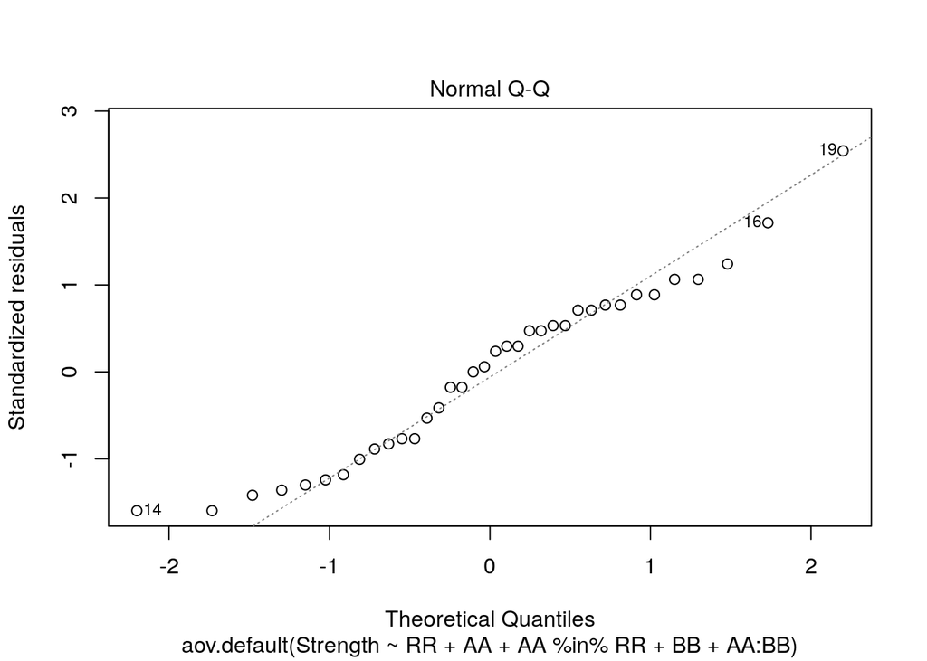

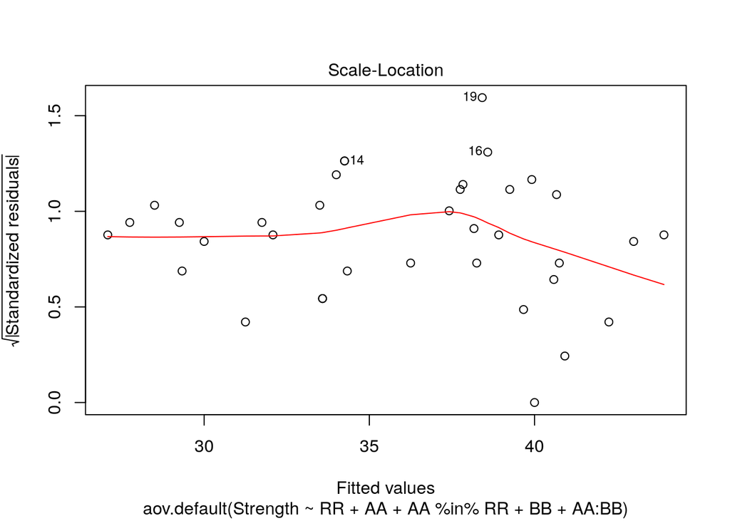

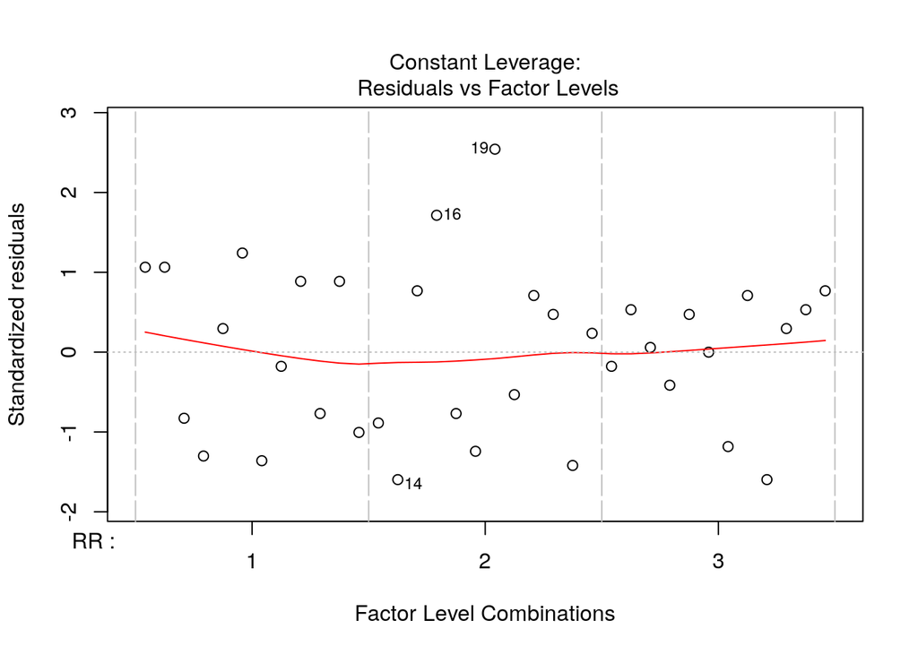

```r
plot(model_lab5_3)
```

## Lab6

- Nested & Crossed Design

An industrial engineer is studying the hand insertion of electronic components on printed circuit boards to improve the speed of the assembly operation. The engineer has designed three assembly fixtures and two workplace layouts that seem promising.

Operators are required to perform the assembly, and it is decided to randomly select four operators for each fixture–layout combination. However, because the workplaces are in different locations within the plant, it is difficult to use the same four operators for each layout. Therefore, the four operators chosen for layout 1 are different individuals from the four operators chosen for layout 2.

Because there are only three fixtures and two layouts, but the operators are chosen at random, this is a mixed model. The treatment combinations in this design are run in random order, and two replicates are obtained. The assembly times are measured in seconds.

In this experiment, operators are nested within the levels of layouts, whereas fixtures and layouts are arranged in a factorial.

```r
lab6_table <- readxl::read_xlsx("Table14_10.xlsx")
lab6_table$A <- as.factor(lab6_table$Fixture)
lab6_table$B <- as.factor(lab6_table$Layout)
lab6_table$C <- as.factor(lab6_table$Operator)
```

```r
lab6_model1 <- lmer(formula = Time ~ A*B +(1|B:C) + (1|A:B:C), data=lab6_table, REML = TRUE)
summary(lab6_model1)
```

```
## Linear mixed model fit by REML ['lmerMod']
## Formula: Time ~ A * B + (1 | B:C) + (1 | A:B:C)
##    Data: lab6_table
##
## REML criterion at convergence: 187.3
##
## Scaled residuals:
##      Min       1Q   Median       3Q      Max
## -1.47784 -0.69541 -0.04367  0.70205  1.37326
##
## Random effects:
##  Groups   Name        Variance Std.Dev.
##  A:B:C    (Intercept) 1.576    1.256
##  B:C      (Intercept) 1.083    1.041
##  Residual             2.333    1.528
## Number of obs: 48, groups:  A:B:C, 24; B:C, 8
##
## Fixed effects:
##             Estimate Std. Error t value
## (Intercept)  24.7500     0.9781  25.305
## A2            3.7500     1.1711   3.202
## A3           -0.6250     1.1711  -0.534
## B2            1.0000     1.3832   0.723
## A2:B2        -2.1250     1.6562  -1.283
## A3:B2         0.8750     1.6562   0.528
##
## Correlation of Fixed Effects:
##       (Intr) A2     A3     B2     A2:B2
## A2    -0.599
## A3    -0.599  0.500
## B2    -0.707  0.423  0.423
## A2:B2  0.423 -0.707 -0.354 -0.599
## A3:B2  0.423 -0.354 -0.707 -0.599  0.500
```

```r
anova(lab6_model1)
```

```
## Analysis of Variance Table
##     Df Sum Sq Mean Sq F value
## A    2 35.213 17.6063  7.5456
## B    1  0.795  0.7949  0.3407
## A:B  2  8.099  4.0494  1.7354
```

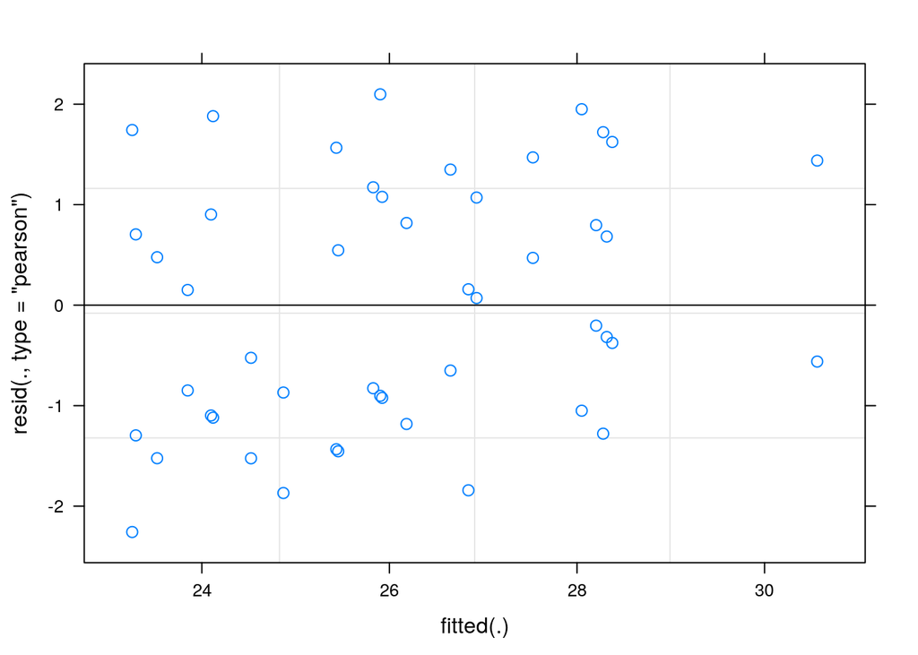

```r
plot(lab6_model1)
```

```r
confint(lab6_model1)
```

```
## Computing profile confidence intervals ...
```

```
##                 2.5 %     97.5 %
## .sig01       0.000000  1.8388093
## .sig02       0.000000  2.0386278
## .sigma       1.179506  2.0839531
## (Intercept) 23.006044 26.4939562
## A2           1.636678  5.8633221
## A3          -2.738322  1.4883221
## B2          -1.466326  3.4663265
## A2:B2       -5.113689  0.8636888
## A3:B2       -2.113689  3.8636888
```

```r
lab6_model11 <- lmer(formula = Time ~ A*B +(1|B:C) + A:(1|B:C), data=lab6_table, REML = TRUE)
summary(lab6_model11)
```

```
## Linear mixed model fit by REML ['lmerMod']
## Formula: Time ~ A * B + (1 | B:C) + A:(1 | B:C)
##    Data: lab6_table
##
## REML criterion at convergence: 190.5
##
## Scaled residuals:
##      Min       1Q   Median       3Q      Max
## -1.90681 -0.58962 -0.00147  0.65057  1.69445
##
## Random effects:
##  Groups   Name        Variance Std.Dev.
##  B.C      (Intercept) 0.3686   0.6072
##  B.C.1    (Intercept) 1.0650   1.0320
##  Residual             3.3843   1.8396
## Number of obs: 48, groups:  B:C, 8
##
## Fixed effects:
##             Estimate Std. Error t value
## (Intercept)  24.7500     0.8840  27.998
## A2            3.7500     0.9198   4.077
## A3           -0.6250     0.9198  -0.679
## B2            1.0000     1.2502   0.800
## A2:B2        -2.1250     1.3008  -1.634
## A3:B2         0.8750     1.3008   0.673
##
## Correlation of Fixed Effects:
##       (Intr) A2     A3     B2     A2:B2
## A2    -0.520
## A3    -0.520  0.500
## B2    -0.707  0.368  0.368
## A2:B2  0.368 -0.707 -0.354 -0.520
## A3:B2  0.368 -0.354 -0.707 -0.520  0.500
## convergence code: 0
## unable to evaluate scaled gradient
## Model failed to converge: degenerate  Hessian with 1 negative eigenvalues
```

```r
anova(lab6_model11)
```

```
## Analysis of Variance Table
##     Df Sum Sq Mean Sq F value
## A    2 82.792  41.396 12.2319
## B    1  1.153   1.153  0.3407
## A:B  2 19.042   9.521  2.8133
```

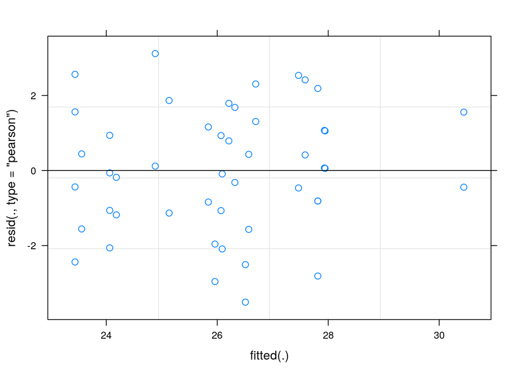

```r
plot(lab6_model11)
```

```r
confint(lab6_model11)
```

```
## Computing profile confidence intervals ...
```

```
##                 2.5 %     97.5 %
## .sig01       0.000000        Inf
## .sig02       0.000000        Inf
## .sigma       1.422847  2.2105970
## (Intercept) 23.111155 26.3888451
## A2           1.997812  5.5021884
## A3          -2.377188  1.1271884
## B2          -1.317677  3.3176770
## A2:B2       -4.602969  0.3529686
## A3:B2       -1.602969  3.3529686
```

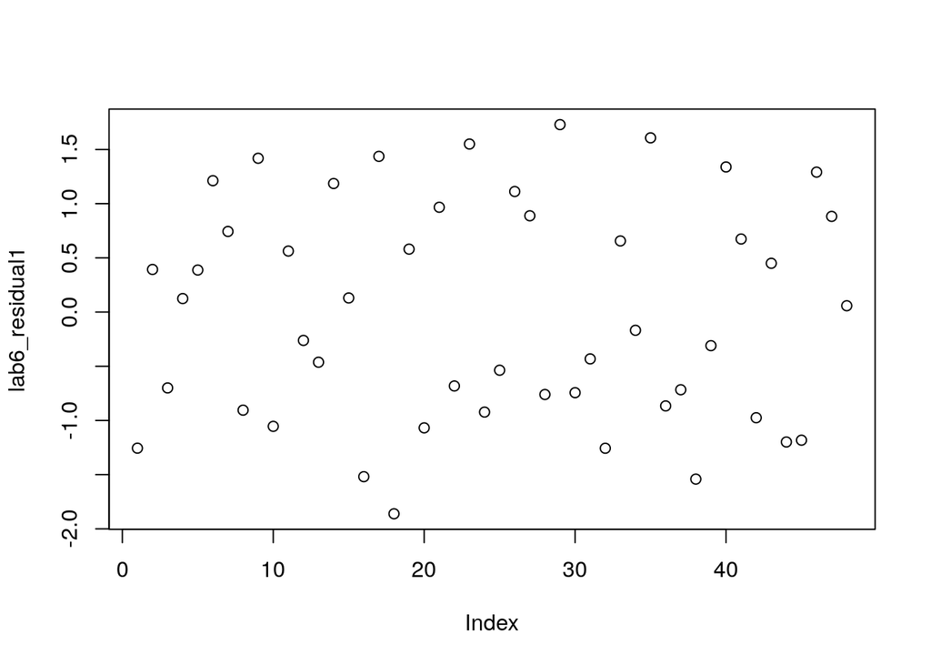

```r
lab6_residual1 <- rstudent(lab6_model1)
lab6_y_hat1 <- fitted(lab6_model1)
plot(lab6_residual1)
```

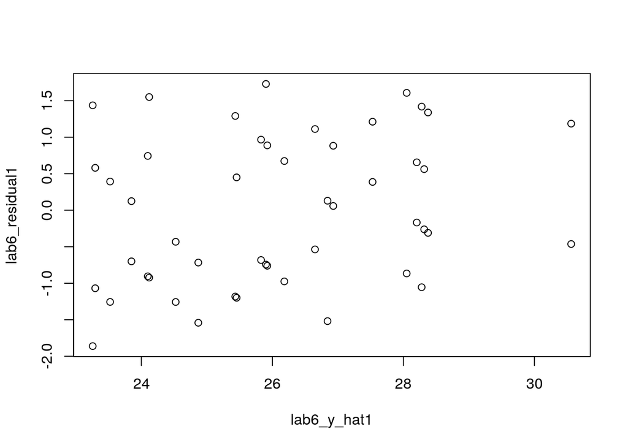

```r
plot(lab6_y_hat1,lab6_residual1)
```

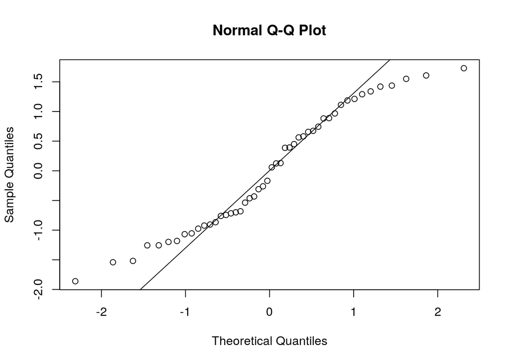

```r
qqnorm(lab6_residual1) ; qqline(lab6_residual1)
```

```r
lab6_model2 <- lmer(formula = Time ~ A*B +(1|B:C) + (1|A:B:C), data=lab6_table, REML = FALSE)
summary(lab6_model2)
```

```
## Linear mixed model fit by maximum likelihood  ['lmerMod']
## Formula: Time ~ A * B + (1 | B:C) + (1 | A:B:C)
##    Data: lab6_table
##
##      AIC      BIC   logLik deviance df.resid
##    214.8    231.6    -98.4    196.8       39
##
## Scaled residuals:
##      Min       1Q   Median       3Q      Max
## -1.53402 -0.67241 -0.07479  0.74310  1.50368
##
## Random effects:
##  Groups   Name        Variance Std.Dev.
##  A:B:C    (Intercept) 0.8906   0.9437
##  B:C      (Intercept) 0.8125   0.9014
##  Residual             2.3333   1.5275
## Number of obs: 48, groups:  A:B:C, 24; B:C, 8
##
## Fixed effects:
##             Estimate Std. Error t value
## (Intercept)   24.750      0.847  29.220
## A2             3.750      1.014   3.697
## A3            -0.625      1.014  -0.616
## B2             1.000      1.198   0.835
## A2:B2         -2.125      1.434  -1.482
## A3:B2          0.875      1.434   0.610
##
## Correlation of Fixed Effects:
##       (Intr) A2     A3     B2     A2:B2
## A2    -0.599
## A3    -0.599  0.500
## B2    -0.707  0.423  0.423
## A2:B2  0.423 -0.707 -0.354 -0.599
## A3:B2  0.423 -0.354 -0.707 -0.599  0.500
```

```r
anova(lab6_model2)
```

```
## Analysis of Variance Table
##     Df Sum Sq Mean Sq F value
## A    2 46.950 23.4751 10.0608
## B    1  1.060  1.0599  0.4542
## A:B  2 10.798  5.3992  2.3139
```